# complete_the_square_C

## complete_the_square_C

#### Question

1. A wrap-around L-shaped patio will measure 14 feet along each wall. The patio will stick out $x$ feet from the walls, and the total area will be 429 square feet. *Note: you can assume all angles are right angles.*

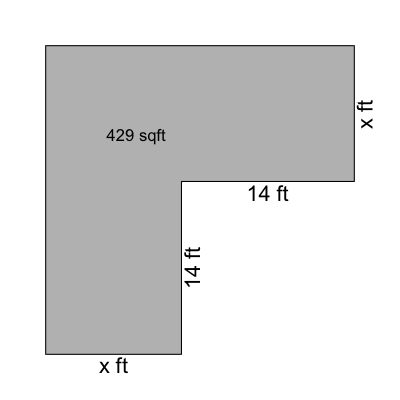

   What value of $x$ satisfies the conditions stated above?

#### Question

2. A wrap-around L-shaped patio will measure 9 feet along each wall. The patio will stick out $x$ feet from the walls, and the total area will be 208 square feet. *Note: you can assume all angles are right angles.*

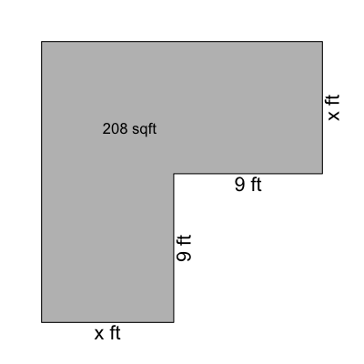

   What value of $x$ satisfies the conditions stated above?

#### Question

3. A wrap-around L-shaped patio will measure 30 feet along each wall. The patio will stick out $x$ feet from the walls, and the total area will be 1404 square feet. *Note: you can assume all angles are right angles.*

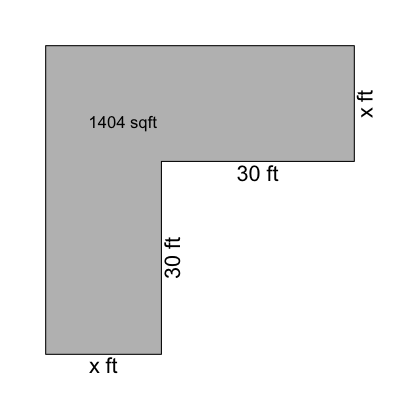

   What value of $x$ satisfies the conditions stated above?

#### Question

4. A wrap-around L-shaped patio will measure 25 feet along each wall. The patio will stick out $x$ feet from the walls, and the total area will be 1491 square feet. *Note: you can assume all angles are right angles.*

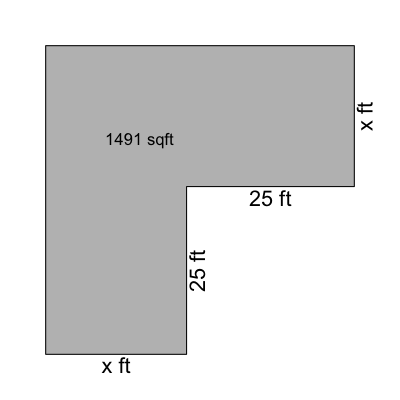

   What value of $x$ satisfies the conditions stated above?

#### Question

5. A wrap-around L-shaped patio will measure 26 feet along each wall. The patio will stick out $x$ feet from the walls, and the total area will be 480 square feet. *Note: you can assume all angles are right angles.*

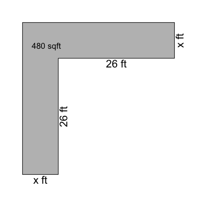

   What value of $x$ satisfies the conditions stated above?

#### Question

6. A wrap-around L-shaped patio will measure 30 feet along each wall. The patio will stick out $x$ feet from the walls, and the total area will be 2464 square feet. *Note: you can assume all angles are right angles.*

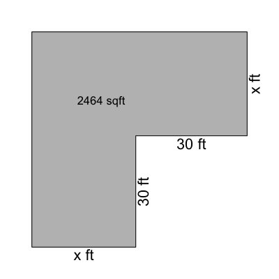

   What value of $x$ satisfies the conditions stated above?